# Association of Same-Day Ambient Fine Particulate Matter with Mortality

Anton Roche, Grace Gaultier, and Joel Chavez Ortiz

ID 271 - Midterm

### Background

Emissions from both natural and anthropogenic sources can create particulate matter (PM) small enough to contribute to adverse health effects in humans (e.g., damage to lung function, asthma) and contribute to environmental damage (e.g., acid rain effects, disruption of nutrient balance in soil and rivers)$\text{.}^{1}$ PM with a diameter of 2.5 micrometers or smaller $\text{PM}_{2.5}$ are considered fine inhalable particles that can penetrate deeper into the lungs than larger PM. Houston is a large U.S. city with a large urban population. High PM emissions from vehicles, industry, and other sources may pose a risk to population health. An observational time-series analysis was conducted to further understand the association between same-day ambient concentrations of $\text{PM}_{2.5}$ and daily mortality.

### Methods

Using historical records data from Houston between January 1, 1999 and December 31, 2006, daily deaths, $\text{PM}_{2.5}$ concentration, and meteorologic were extracted to analyze the association between $\text{PM}_{2.5}$ and three outcomes of interest: all-cause mortality, cardiovascular (CVD) disease-related mortality, and respiratory disease-related mortality. Days in our study period without an average $\text{PM}_{2.5}$ were excluded.

#### Study Analysis

Penalized splines were initially fit for relative humidity (RH) and temperature. Through the flexible modeling, RH and temperature were found to have linear relationships with the outcomes of interest, so the models were refit with RH and temperature as linear predictors. Splines were fit with cubic regression smoothing functions generated from restricted maximum likelihood (REML) for more stable parameter estimation and less overfitting. Analysis of variance (ANOVA) tests were conducted for each outcome, testing the null hypothesis that the model without temperature was sufficient, and the alternative hypothesis that temperature is necessary in the model.

Model for all-cause and respiratory mortality:

$$\text{log}(\mathbb{E}[Y_{t}]) =
\beta_{0} +f_{1}(Time_{t})+\beta_{1}(PM_{t})
+\beta_{2}Temp_{t}+\beta_{3}RH_{t}+\beta_{4}Dow_{t}$$

Where $Y_t$ is the count of mortality (all-cause or respiratory) on day t since the beginning of the study, RH is the same day average relative humidity (%), Temp is the same day average temperature (Fahrenheit), $\text{PM}_{2.5}$ is the same day average fine particulate matter concentration (in $\mu g/m^3$), and day of week (dow) was included as an indicator variable in this model.

Model for CVD mortality:

$$\text{log}(\mathbb{E}[Y_{t}]) =
\beta_{0}
+f_{1}(PM_{t})+f_{2}(Time_{t})+\beta_{1}Temp_{t}+\beta_{2}RH_{t}+\beta_{3}Dow_{t}$$
Where $Y_t$ is the count of mortality (CVD) on day t since the beginning of the study, RH is the same day average relative humidity (%), Temp is the same day average temperature (Fahrenheit), $\text{PM}_{2.5}$ is the same day average fine particulate matter concentration (in $\mu g/m^3$), and day of week (dow) was included as an indicator variable in this model.

### Results

Table 1. Descriptive Statistics of Daily Mortality, Daily Particulate Matter, and Weather, Houston 1999-2006

|  | Descriptive Statistic Values (N=2523) |
| --- | --- |
| All-cause mortality, daily |  |
| Mean (SD) | 50.26 (7.91) |
| Variance | 62.56 |
| Min, Median, Max | 23, 50, 82 |
| ~Total Deaths, 1999-2006 | 126,802 |
| Cardiovascular mortality, daily |  |
| Mean (SD) | 14.89 (4.09) |
| Variance | 16.70 |
| Min, Median, Max | 3, 15, 33 |
| ~Total Deaths, 1999-2006 | 37,578 |
| Respiratory mortality, daily |  |
| Mean (SD) | 3.99 (2.16) |
| Variance | 4.67 |
| Min, Median, Max | 0, 4, 13 |
| ~Total Deaths, 1999-2006 | 10,066 |
| PM2.5, µg/m³ |  |
| Mean (SD) | 12.91 (5.58) |
| Min, Median, Max | 0.5, 12, 53 |
| Temperature, °F |  |
| Mean (SD) | 69.90 (11.93) |
| Min, Median, Max | 34.0, 72, 92 |
| Relative Humidity, % |  |
| Mean (SD) | 73.08 (12.87) |
| Min, Median, Max | 25.6, 75, 100 |

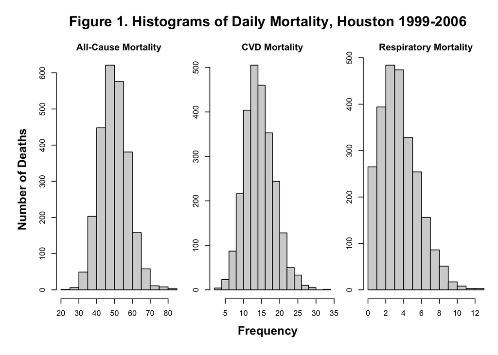

When $\text{PM}_{2.5}$ was fit with a penalized spline for the all-cause and respiratory mortality models, the estimated degrees of freedom was 1 for each (Supplemental). However, the model for CVD mortality showed an estimated df of 2.18, signifying a non-linear relationship (Figure 2). The dose-response curves for the all-cause mortality and respiratory outcomes show a linear, positive relationship $\text{PM}_{2.5}$ concentrations, with respiratory disease having larger relative risk estimates as $\text{PM}_{2.5}$ increases. For the $\text{PM}_{2.5}$-CVD mortality plot, the log rate ratio peaks around 17 $\mu g/m^3$, followed by a gradual decrease at higher concentrations. The confidence intervals for all-cause and CVD mortality are wide, with the former’s lower boundary crossing 1. Due to the non-linear relationship between CVD and $\text{PM}_{2.5}$, it would not be appropriate to calculate relative risk. A 10 $\mu g/m^3$ increase in $\text{PM}_{2.5}$ was associated with a 1% increase in all-cause mortality (RR=1.01, 95% CI: 0.999, 1.021) 5% increase in respiratory mortality (RR=1.05, 95% CI: 1.012, 1.092) [Table 2].

**Table 2. Coefficient p-value for PM2.5 Models Where Exposure-Response Relationship was Linear**

Relative risk per 10 µg/m³ increase

[output not shown]

Testing the significance of temperature as a covariate, the ANOVA result for the all-cause mortality model showed a p-value below 0.05 (p-value=0.0005; residual deviance of 2583.8 and 2571.5). However, the results for CVD and respiratory mortality showed large p-values (p-values of 0.38 and 0.48, respectively). Fitting a penalized spline to temperature resulted in estimated degrees of freedom of 1 for all three of our outcomes (Supplemental). The refitted dose-response curves show a positive, linear relationship between temperature and daily mortality (Figure 3). However, the confidence intervals of the relative risk for each model is wide, crossing 1 for both the CVD and respiratory mortality models where temperatures are probable (e.g, mortality temperature below -20 might not provide relevant public health information to the citizens of Houston). All-cause mortality maintained an estimated relative risk above 1 for each observed temperature.

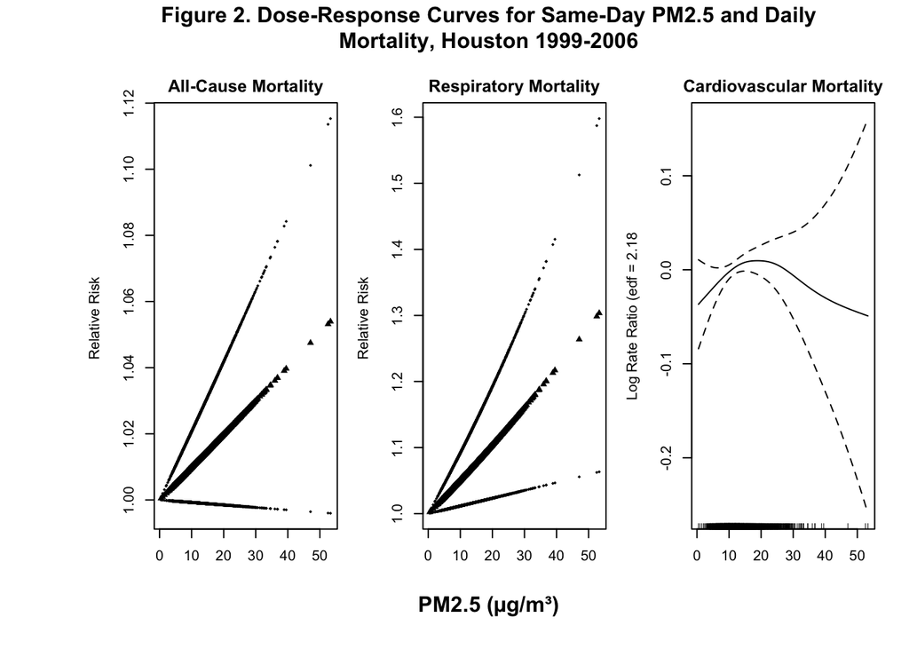

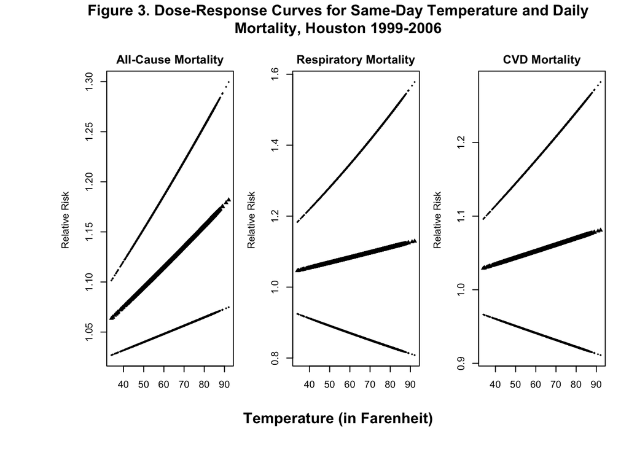

### Discussion

These results on the association between same-day $\text{PM}_{2.5}$ and daily mortality provide some evidence that there is a significant relationship between the two. However, significance seems only to apply to daily mortality of a certain kind. The dose-response curve for $\text{PM}_{2.5}$ and respiratory mortality had only positive relative risk estimates and the confidence bands did not cross 1. Unlike the other two outcomes, this provides evidence that there is a significant, positive, and linear relationship between $\text{PM}_{2.5}$ and respiratory mortality. Additional evidence of this can be seen in the confidence interval for a 10-unit increase of $\text{PM}_{2.5}$, as the interval doesn’t contain 1.

This study was subject to limitations. Although the ANOVA results for two of the outcomes indicated temperature should not be included in the model, the choice was made to include it. Previous studies have noted temperature as a confounder between $\text{PM}_{2.5}$ and mortality. Even though adjusting for time and RH might have accounted for most of the possible confounding, adjusting for temperature might reduce residual confounding. There are many ways to fit splines to capture trends and seasonality. One option was to fit a penalized spline using restricted maximum likelihood, as this allows our df to adjust to our data. One disadvantage of the natural spline we fit to time is that the choice of df is arbitrary and restricts flexibility and adaption to the structure of the data. Additionally, this study did not account for the lagged effect of $\text{PM}_{2.5}$ concentrations. The lagged effect of $\text{PM}_{2.5}$ might be significant driver in mortality, but that was not explored in this analysis. The lagged association of temperature and RH with $\text{PM}_{2.5}$ and mortality was not assessed.

Overall, respiratory and same-day $\text{PM}_{2.5}$ in Houston might have a moderate linear relationship. Reduction in emissions might prove to lower overall respiratory mortality. Further studies are needed to assess the lagged effect of $\text{PM}_{2.5}$ and different forms of mortality. Additionally, studies regarding $\text{PM}_{2.5}$ and it’s effect on other outcomes (e.g., neuro-cognitive disorders) will create a better public health understanding of the impacts of this pollutant.

### References

1. EPA. Particulate Matter (PM) Basics. https://www.epa.gov/pm-pollution/particulate-matter-pm-basics. Last updated May 2025.
2. Chao, C. Y., Li, W., Hopke, P. K., Guo, F., Wang, Y., & Griffin, R. J. (2025). Increases in PM2.5 levels in Houston are associated with a highly recirculating sea breeze. Environmental pollution (Barking, Essex : 1987), 366, 125381. https://doi.org/10.1016/j.envpol.2024.125381

### Supplemental

```
##          var  edf_tot    p_val_tot  edf_cvd p_val_cvd edf_resp p_val_resp
## 1   TEMP_GCV 1.000269 0.0005723577 1.000963 0.4387030 1.000894 0.47673577
## 2  PM2.5_GCV 1.001699 0.0691777549 6.481029 0.1363489 1.001525 0.01088204
## 3     RH_GCV 1.000603 0.6384481078 2.226630 0.2790598 1.000633 0.33776373
## 4  TEMP_REML 1.000363 0.0005727835 1.001943 0.3735178 1.001234 0.47700674
## 5 PM2.5_REML 1.002334 0.0692918688 2.183009 0.2695712 1.001551 0.01088321
## 6    RH_REML 1.000334 0.6382011525 2.323856 0.2526896 1.001054 0.33798000
```

```r
mod_tot<-gam(tot ~  s(pm25) + s(time,bs = "cr",fx=TRUE,k=41)+TEMP+ RH + as.factor(dow), family=quasipoisson, data=hou_pm, method="REML")


mod_cvd<-gam(cvd ~ s(pm25) + s(time,bs = "cr",fx=TRUE,k=41)+TEMP+ RH + as.factor(dow), family=quasipoisson, data=hou_pm, na.action=na.omit, method="REML")

mod_resp<-gam(resp ~ pm25 + s(time,bs = "cr",fx=TRUE,k=41)+TEMP+ RH + as.factor(dow), family=quasipoisson, data=hou_pm, method="REML")
```

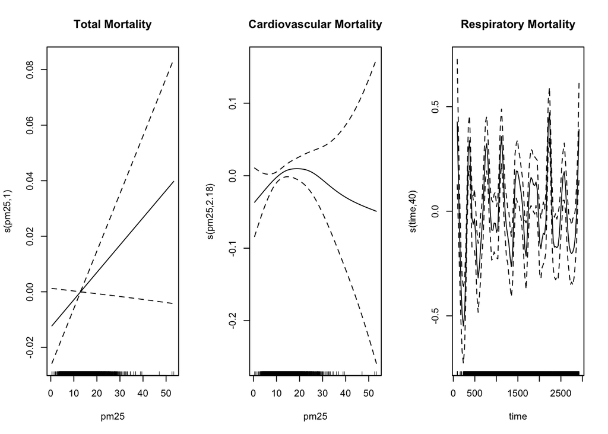

```r
par(mfrow=c(1,3))
plot(mod_tot,  select=1, scale=0, main="Total Mortality")
plot(mod_cvd,  select=1, scale=0, main="Cardiovascular Mortality")
plot(mod_resp, select=1, scale=0, main="Respiratory Mortality",)
```